# West_Europe

```python
import numpy as np
import pandas as pd
import matplotlib.pyplot as plt
import seaborn as sns
```

```python
wc = pd.read_csv("Western_Europe_City.csv")
wr = pd.read_csv("Western_Europe_Resort.csv")
base = pd.read_csv("city.csv")
bas = pd.read_csv("resort.csv")
```

```python
bas1 = bas.loc[(base["continent"]=="Europe")]
print(len(bas1))
print(len(wr))
len(wr)/len(bas1)*100
```

```
29348
4049
```

```
13.796510835491347
```

```python
base1 = base.loc[(base["continent"]=="Europe")]
base2 = base1.loc[(base1['country_decoded']=='Portugal')]
print(len(base2)/len(base1)*100)
len(wc)/len(base1)*100
```

```
28.608505997818973
```

```
40.95092693565976
```

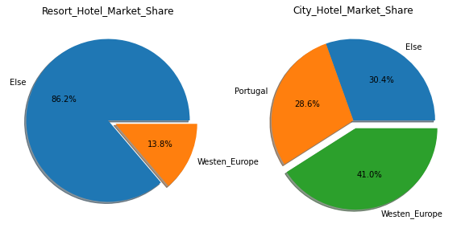

```python
# Pie chart, where the slices will be ordered and plotted counter-clockwise:
labels = 'Else','Westen_Europe'
fracs = [86.20, 13.80]
labels1 = 'Else', 'Portugal','Westen_Europe'
fracs1 = [30.44,28.61,40.95]

# Make figure and axes
fig, axs = plt.subplots(1, 2,figsize = (10,5))

# A standard pie plot
axs[0].pie(fracs, labels=labels, autopct='%1.1f%%', shadow=True,
          explode=(0, 0.1))
axs[0].set_title("Resort_Hotel_Market_Share")

# Shift the second slice using explode
axs[1].pie(fracs1, labels=labels1, autopct='%1.1f%%', shadow=True,
              explode=(0,0,0.1))
axs[1].set_title("City_Hotel_Market_Share")


plt.show()
```

```python
wc.head().iloc[:,9:20]
```

|  | stays_in_week_nights | adults | children | babies | meal | country | market_segment | distribution_channel | is_repeated_guest | previous_cancellations | previous_bookings_not_canceled |
| --- | --- | --- | --- | --- | --- | --- | --- | --- | --- | --- | --- |
| 0 | 1 | 2 | 0.0 | 0 | HB | ITA | Offline TA/TO | TA/TO | 0 | 0 | 0 |
| 1 | 1 | 2 | 0.0 | 0 | HB | ITA | Offline TA/TO | TA/TO | 0 | 0 | 0 |
| 2 | 1 | 2 | 0.0 | 0 | HB | ITA | Offline TA/TO | TA/TO | 0 | 0 | 0 |
| 3 | 1 | 2 | 0.0 | 0 | HB | ITA | Groups | TA/TO | 0 | 0 | 0 |
| 4 | 1 | 2 | 0.0 | 0 | HB | ITA | Offline TA/TO | TA/TO | 0 | 0 | 0 |

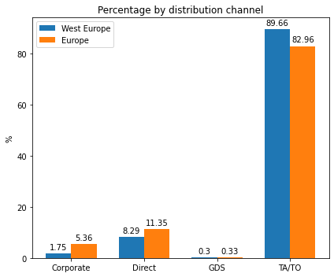

```python
labels = wc.groupby(['distribution_channel'])['distribution_channel'].count().index
west_E = (wc.groupby(['distribution_channel'])['distribution_channel'].count()/len(wc)*100).round(2).iloc[0:4]
E = (base1.groupby(['distribution_channel'])['distribution_channel'].count()/len(base1)*100).round(2).iloc[0:4]

x = np.arange(len(labels))  # the label locations
width = 0.35  # the width of the bars

fig, ax = plt.subplots(figsize = (6,5))
rects1 = ax.bar(x - width/2, west_E, width, label='West Europe')
rects2 = ax.bar(x + width/2, E, width, label='Europe')

# Add some text for labels, title and custom x-axis tick labels, etc.
ax.set_ylabel('%')
ax.set_title('Percentage by distribution channel')
ax.set_xticks(x)
ax.set_xticklabels(labels)
ax.legend()


def autolabel(rects):
    """Attach a text label above each bar in *rects*, displaying its height."""
    for rect in rects:
        height = rect.get_height()
        ax.annotate('{}'.format(height),
                    xy=(rect.get_x() + rect.get_width() / 2, height),
                    xytext=(0, 3),  # 3 points vertical offset
                    textcoords="offset points",
                    ha='center', va='bottom')


autolabel(rects1)
autolabel(rects2)

fig.tight_layout()

plt.show()
```

- TA/TO 즉, 여행사를 통해서 호텔을 예약을 하는 비율이 훨씬 높은 것을 확인할 수 있었다.
- 퍼센트 포인트만 본다면 대략 7%p정도 밖에 차이가 나지 않지만, 역으로 생각해보면 여행사를 통해서 예약하지 않는 경우는 17% => 10.5%로, 40% 가량 적은 것을 확인 할 수 있다.

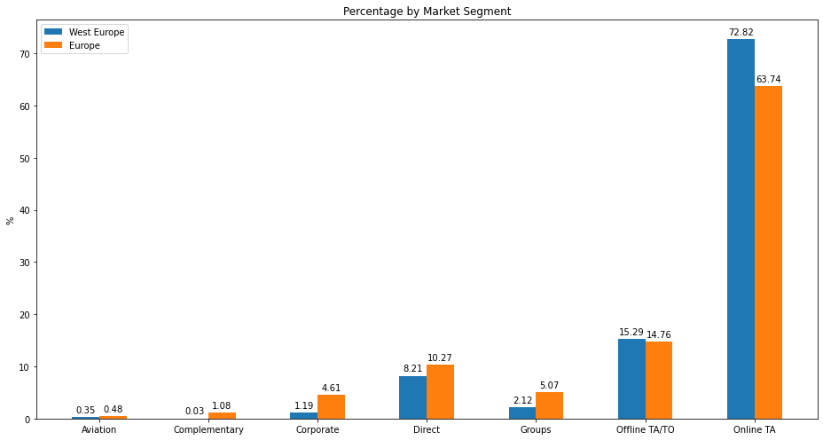

```python
labels = wc.groupby(['market_segment'])['market_segment'].count().index
west_E = (wc.groupby(['market_segment'])['market_segment'].count()/len(wc)*100).round(2).iloc[0:]
E = (base1.groupby(['market_segment'])['market_segment'].count()/len(base1)*100).round(2).iloc[0:]

x = np.arange(len(labels))  # the label locations
width = 0.25  # the width of the bars

fig, ax = plt.subplots(figsize = (13,7))
rects1 = ax.bar(x - width/2, west_E, width, label='West Europe')
rects2 = ax.bar(x + width/2, E, width, label='Europe')

# Add some text for labels, title and custom x-axis tick labels, etc.
ax.set_ylabel('%')
ax.set_title('Percentage by Market Segment')
ax.set_xticks(x)
ax.set_xticklabels(labels)
ax.legend()


def autolabel(rects):
    """Attach a text label above each bar in *rects*, displaying its height."""
    for rect in rects:
        height = rect.get_height()
        ax.annotate('{}'.format(height),
                    xy=(rect.get_x() + rect.get_width() / 2, height),
                    xytext=(0, 3),  # 3 points vertical offset
                    textcoords="offset points",
                    ha='center', va='bottom')


autolabel(rects1)
autolabel(rects2)

fig.tight_layout()

plt.show()
```

- 상대적으로 Online TA 가 기존 Europe에 비해서 다수인 것을 확인할 수 있었다.
- 이에 따라서, 마케팅을 여행사를 집중적으로, 그중에서도 Online 여행사를 기준으로 하면 더욱 좋을 것이다.

#### 그렇다면 어떠한 여행사?

```python
agent = (wc.groupby(['agent'])['hotel'].count()/len(wc)*100).round(2).to_frame().sort_values(by = 'hotel', ascending=False)
agent.head(10)
```

| agent | hotel |
| --- | --- |
| 9 | 62.82 |
| 14 | 6.19 |
| 7 | 5.69 |
| 28 | 5.38 |
| Undefined | 4.16 |
| 8 | 1.31 |
| 27 | 1.29 |
| 6 | 1.10 |
| 1 | 0.98 |
| 85 | 0.93 |

```python
agent = (wr.groupby(['agent'])['hotel'].count()/len(wr)*100).round(2).to_frame().sort_values(by = 'hotel', ascending=False)
agent.head(10)
```

| agent | hotel |
| --- | --- |
| 240 | 48.83 |
| Undefined | 13.02 |
| 250 | 7.43 |
| 6 | 3.58 |
| 241 | 3.28 |
| 251 | 2.45 |
| 298 | 2.40 |
| 242 | 2.20 |
| 464 | 1.68 |
| 314 | 1.36 |

- 서유럽권 기준으로 보았을 때, agent 9번의 점유율이 독과점 수준으로 많다는 것을 확인할 수 있었다.

```python
for i in ([9,14,7,28]):
    wc1 = wc.loc[(wc['agent'] == str(i) )]
    print(i,wc1['market_segment'].value_counts())
```

```
9 Online TA    11795
Name: market_segment, dtype: int64
14 Direct    1163
Name: market_segment, dtype: int64
7 Online TA    1069
Name: market_segment, dtype: int64
28 Offline TA/TO    1010
Name: market_segment, dtype: int64
```

- 당연하게도, 9번의 경우 Online 여행사 였으며 추가적인 인센티브등을 남겨주는게 좋을 듯 싶으며
- 7번의 경우에도 online 여행사이므로 이 여행사에도 추가적인 조치를 취하여 독과점이 되지 않도록 만드는 것이 중요할 것이다.

### 결론

- City Hotel을 마케팅하기 위해서는 OnlineTA를 보아야하고 대부분은 agent 9번이 독과점하고 있으므로 좋은 관계를 유지하되, 2등인 7번도 적극적인 지원을 해주어 경쟁을 유도하고 그에 따른 이익을 챙길 필요가 있겠다.